# Análisis de Habilidades Blandas en Postgrados (Sección Argentina)

Campo Elías López y Juan C. Correa

2024-06-23

# Carga de datos

Primero, se carga el paquete “readtext” y se lee el directorio “Argentina” para extraer los textos de los documentos PDF. Luego, se elimina la extensión “.pdf” del identificador de cada documento.

```r
library(readtext)
ARG <- readtext("Argentina")
ARG$doc_id <- gsub(".pdf", "", ARG$doc_id)
```

Luego, pasamos a relacionar cada programa de postgrado con su correspondiente nivel educativo para observar cuántos programas hay de cada nivel:

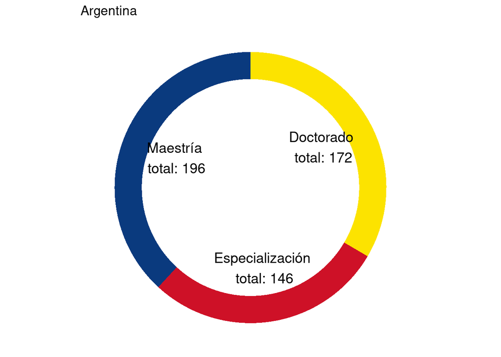

```r
library(dplyr)
ARG <- mutate(ARG,
              Program = ifelse(
                grepl("Doctorado en", text), "Doctorado",
                ifelse(grepl("Maestría|Magíster en|MAGISTER EN", text), "Maestría",
                       "Especialización")))
Programas <- data.frame(table(ARG$Program))
colnames(Programas)[1] <- "Programa"
colnames(Programas)[2] <- "Total"

library(ggplot2)
Programas$fraction = Programas$Total / sum(Programas$Total)
Programas$ymax = cumsum(Programas$fraction)
Programas$ymin = c(0, head(Programas$ymax, n=-1))
Programas$ymax <- cumsum(Programas$fraction)
Programas$ymin <- c(0, head(Programas$ymax, n=-1))
Programas$labelPosition <- (Programas$ymax + Programas$ymin) / 2
Programas$label <- paste0(Programas$Programa, "\n total: ", Programas$Total)
ggplot(Programas, aes(ymax=ymax, ymin=ymin, xmax=4, xmin=3, fill=Programa)) +
  geom_rect() +
  geom_text(x=2, aes(y=labelPosition, label=label, color=Programa), size=5) +
  scale_fill_manual(values=c("Doctorado"="#FCE300", "Maestría"="#0A3A7E", "Especialización"="#CE1127")) +
  scale_color_manual(values=c("Doctorado"="black", "Maestría"="black", "Especialización"="black")) + # Custom text colors
  coord_polar(theta="y") +
  xlim(c(-1, 4)) +
  theme_void() +
  theme(legend.position = "none") +
  ggtitle("Argentina")
```

Ahora, pasamos a crear el corpus lingüístico. Para ello, cada documento se va a descomponer en número de palabras totales (tokens), número de palabras únicas (types) y número de oraciones (sentences). Esto nos permitirá observar la longitud de cada oferta de postgrado.

```r
library(quanteda)
TextsARG <- corpus(ARG$text)
docvars(TextsARG, "Program") <- ARG$Program
docvars(TextsARG, "Country") <- "Argentina"
head(summary(TextsARG), 3)
```

```
##    Text Types Tokens Sentences         Program   Country
## 1 text1   603   1699        52 Especialización Argentina
## 2 text2   368    755        28 Especialización Argentina
## 3 text3   267    551        34 Especialización Argentina
```

```r
ProgramsARG <- tokens(TextsARG,
                     remove_numbers = TRUE,
                     remove_punct = TRUE,
                     remove_url = TRUE,
                     remove_symbols = TRUE) %>%
  tokens_remove(stopwords("spanish"))
```

Ahora, pasamos a hacer a buscar con el filtro contextual así:

```r
s1 <- data.frame(kwic(ProgramsARG, pattern = phrase("pensamiento crítico")))
s2 <- data.frame(kwic(ProgramsARG, pattern = phrase("solucionar problemas")))
s3 <- data.frame(kwic(ProgramsARG, pattern = "comunicar"))
s4 <- data.frame(kwic(ProgramsARG, pattern = "creatividad"))
s5 <- data.frame(kwic(ProgramsARG, pattern = "paciencia"))
s6 <- data.frame(kwic(ProgramsARG, pattern = "crear"))
s7 <- data.frame(kwic(ProgramsARG, pattern = "liderar"))
s8 <- data.frame(kwic(ProgramsARG, pattern = "resolver"))
s9 <- data.frame(kwic(ProgramsARG, pattern = "comprometer"))
s10 <- data.frame(kwic(ProgramsARG, pattern = "comprometerse"))
s11 <- data.frame(kwic(ProgramsARG, pattern = "gestionar"))
s12 <- data.frame(kwic(ProgramsARG, pattern = "reflexionar"))
s13 <- data.frame(kwic(ProgramsARG, pattern = "controlar"))
s14 <- data.frame(kwic(ProgramsARG, pattern = "ético"))
s15 <- data.frame(kwic(ProgramsARG, pattern = "tolerar"))
s16 <- data.frame(kwic(ProgramsARG, pattern = "argumentar"))
s17 <- data.frame(kwic(ProgramsARG, pattern = "conflictos"))
s18 <- data.frame(kwic(ProgramsARG, pattern = "negociar"))
s19 <- data.frame(kwic(ProgramsARG, pattern = "comprender"))
s20 <- data.frame(kwic(ProgramsARG, pattern = "equipos"))
s21 <- data.frame(kwic(ProgramsARG, pattern = "planificar"))
s22 <- data.frame(kwic(ProgramsARG, pattern = "generar"))
s23 <- data.frame(kwic(ProgramsARG, pattern = "empatía"))
s24 <- data.frame(kwic(ProgramsARG, pattern = "compartir"))
s25 <- data.frame(kwic(ProgramsARG, pattern = "analizar"))
s26 <- data.frame(kwic(ProgramsARG, pattern = "reconocer"))
s27 <- data.frame(kwic(ProgramsARG, pattern = "orientar"))
s28 <- data.frame(kwic(ProgramsARG, pattern = "respetar"))
s29 <- data.frame(kwic(ProgramsARG, pattern = "motivar"))
s30 <- data.frame(kwic(ProgramsARG, pattern = "cooperar"))
s31 <- data.frame(kwic(ProgramsARG, pattern = "fortalecer"))
s32 <- data.frame(kwic(ProgramsARG, pattern = "impulsar"))
s33 <- data.frame(kwic(ProgramsARG, pattern = "acercar"))
s34 <- data.frame(kwic(ProgramsARG, pattern = "ayudar"))
s35 <- data.frame(kwic(ProgramsARG, pattern = "cambiar"))
s36 <- data.frame(kwic(ProgramsARG, pattern = "apreciar"))
s37 <- data.frame(kwic(ProgramsARG, pattern = "dirigir"))
s38 <- data.frame(kwic(ProgramsARG, pattern = "fomentar"))
s39 <- data.frame(kwic(ProgramsARG, pattern = "interactuar"))
s40 <- data.frame(kwic(ProgramsARG, pattern = "identificar"))
s41 <- data.frame(kwic(ProgramsARG, pattern = "competir"))
s42 <- data.frame(kwic(ProgramsARG, pattern = "manifestar"))
s43 <- data.frame(kwic(ProgramsARG, pattern = "responsable"))
s44 <- data.frame(kwic(ProgramsARG, pattern = "evaluar"))
s45 <- data.frame(kwic(ProgramsARG, pattern = "innovar"))
s46 <- data.frame(kwic(ProgramsARG, pattern = "decidir"))
s47 <- data.frame(kwic(ProgramsARG, pattern = phrase("tomar decisiones")))
s48 <- data.frame(kwic(ProgramsARG, pattern = "flexibilidad"))
s49 <- data.frame(kwic(ProgramsARG, pattern = "persua*"))
s50 <- data.frame(kwic(ProgramsARG, pattern = "convencer"))

df_list <- mget(paste0("s", 1:50))
SS <- do.call(rbind, df_list)
SS$Skill <- rownames(SS)
SS$Skill <- gsub("\\..*", "", SS$Skill)

SkillsARG <- data.frame(Country = "Argentina",
                        SkillCode = c(paste0("s", 1:50)),
                        Skill = c("pensamiento crítico",
                                  "solucionar problemas",
                                  "comunicar",
                                  "creatividad",
                                  "paciencia",
                                  "crear",
                                  "liderar",
                                  "resolver",
                                  "comprometer",
                                  "comprometerse",
                                  "gestionar",
                                  "reflexionar",
                                  "controlar",
                                  "ético",
                                  "tolerar",
                                  "argumentar",
                                  "conflictos",
                                  "negociar",
                                  "comprender",
                                  "equipos",
                                  "planificar",
                                  "generar",
                                  "empatía",
                                  "compartir",
                                  "analizar",
                                  "reconocer",
                                  "orientar",
                                  "respetar",
                                  "motivar",
                                  "cooperar",
                                  "fortalecer",
                                  "impulsar",
                                  "acercar",
                                  "ayudar",
                                  "cambiar",
                                  "apreciar",
                                  "dirigir",
                                  "fomentar",
                                  "interactuar",
                                  "identificar",
                                  "competir",
                                  "manifestar",
                                  "responsable",
                                  "evaluar",
                                  "innovar",
                                  "decidir",
                                  "tomar decisiones",
                                  "flexibilidad",
                                  "persua*",
                                  "convencer"))
```

# Paso 2: (Modelado de Red de Habilidades)

Ahora, pasamos a modelar las relaciones entre las habilidades y los programas de postgrado. Para ello, vamos a usar los datos de la tabla SS resultante del último código del paso anterior para construir la redd a través de una lista de aristas.

```r
networkARG <- SS[c(1,8)]
head(networkARG, 3)
```

```
##      docname Skill
## s1.1  text15    s1
## s1.2  text66    s1
## s1.3  text98    s1
```

Ahora, pasamos a graficar la red bipartita entre habilidades y programas

```r
library(igraph)
bn6 <- graph.data.frame(networkARG,directed=FALSE)
bipartite_mapping(bn6)
```

[output not shown]

[output cut: 33 more lines]

[output not shown]

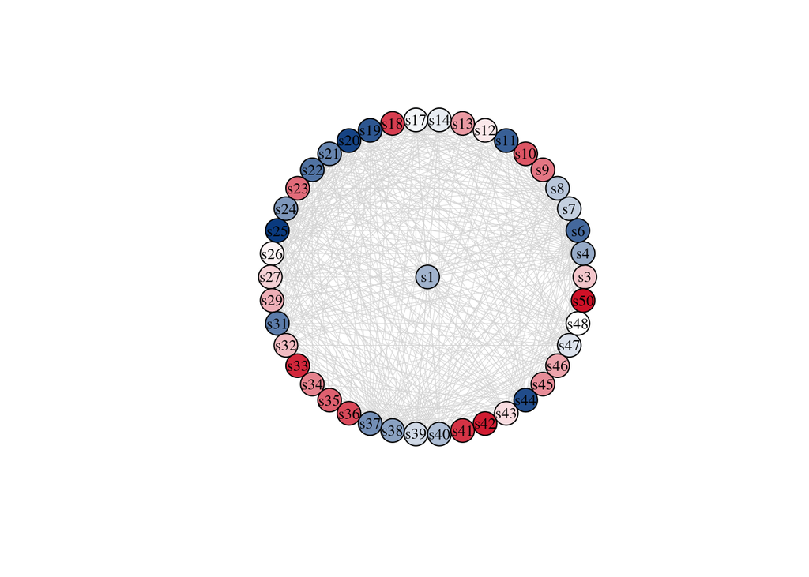

```r
V(bn6)$type <- bipartite_mapping(bn6)$type
V(bn6)$shape <- ifelse(V(bn6)$type, "circle", "square")
V(bn6)$label.cex <- ifelse(V(bn6)$type, 0.5, 1)
V(bn6)$size <- sqrt(igraph::degree(bn6))
E(bn6)$color <- "lightgrey"

bn6.pr <- bipartite_projection(bn6)
Terms <- bn6.pr$proj2

pave <- data.frame(igraph::betweenness(Terms))

centrality_scores <- igraph::eigen_centrality(Terms)
centrality_scores <- centrality_scores$vector

color_palette <- colorRampPalette(c("#CE1127", "white", "#0A3A7E"))(length(unique(centrality_scores)))

# Assign ARGors to nodes based on their normalized centrality scores
node_colors <- color_palette[rank(centrality_scores)]

# Plot the network with node ARGors based on centrality
set.seed(915)


plot(Terms, vertex.label.color = "black", vertex.label.cex = 0.8, vertex.color = node_colors, vertex.size = 15, edge.width = 0.5, edge.color = "lightgray", layout = layout_as_star, main = "")
```

Seguimos con el cálculo de la importancia de cada habilidad y analicemos la correlación entre los cuatro indicadores de centralidad para ver si se comportan de una manera semejante a lo esperado por la evidencia empírica sobre indicadores de centralidad.

```r
BNARG <- graph.data.frame(networkARG, directed = FALSE)
ProgramsARG <- data.frame(Degree = igraph::degree(BNARG),
                         Closeness = igraph::closeness(BNARG),
                         Betweennes = igraph::betweenness(BNARG),
                         Eigen = igraph::eigen_centrality(BNARG))
ProgramsARG <- ProgramsARG[ -c(5:25) ]
rownames(ProgramsARG)
```

[output not shown]

[output cut: 44 more lines]

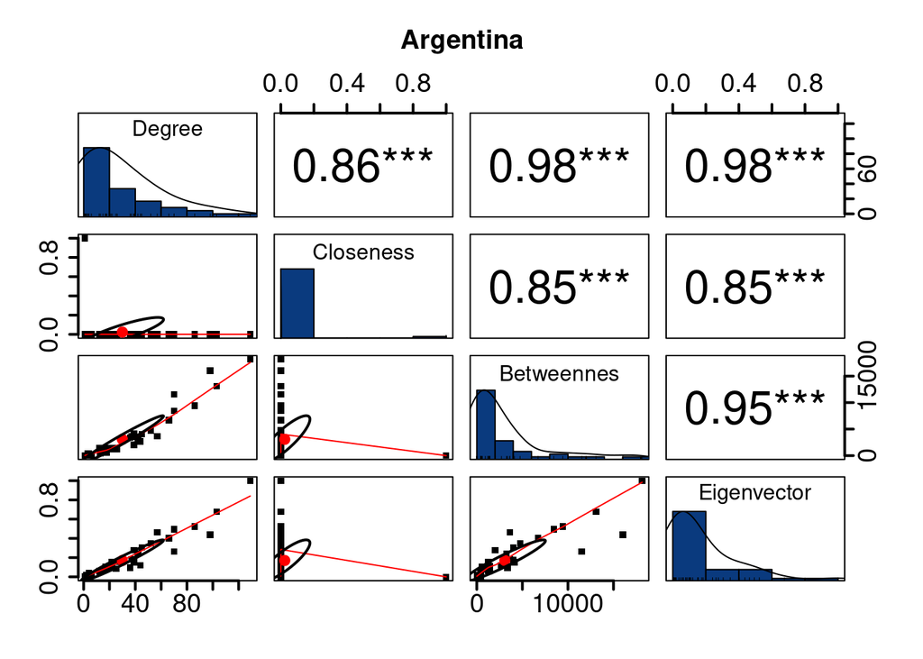

```r
ProgramsARG$SS <- rownames(ProgramsARG)
ProgramsARG <- ProgramsARG[order(ProgramsARG$SS), ]
ProgramsARG <- ProgramsARG[grepl("s", ProgramsARG$SS), ]
ProgramsARG <- ProgramsARG[1:4]
colnames(ProgramsARG)[4] <- "Eigenvector"



library(psych)

pairs.panels(ProgramsARG,
             method = "spearman",
             hist.col = "#0A3A7E",
             density = TRUE,
             ellipses = TRUE,
             pch = 15,
             cex = 1,
             cex.axis = 1.8,
             cex.labels = 1.5,
             lwd = 2,
             rug = TRUE,
             stars = TRUE,
             main = "Argentina")
```

Ahora, veamos el ranking de las diez habilidades más importantes

```r
IARG <- as_biadjacency_matrix(BNARG, names = TRUE, sparse = TRUE, types = bipartite_mapping(BNARG)$type)
IARG2 <- as.matrix(IARG)

rownames(ProgramsARG)[order(ProgramsARG$Eigenvector, decreasing = TRUE)]
```

```
##  [1] "s20" "s25" "s44" "s19" "s11" "s22" "s6"  "s31" "s37" "s21" "s24" "s38"
## [13] "s4"  "s40" "s7"  "s8"  "s1"  "s43" "s39" "s47" "s14" "s17" "s26" "s12"
## [25] "s48" "s27" "s3"  "s32" "s29" "s13" "s46" "s45" "s34" "s9"  "s35" "s23"
## [37] "s36" "s10" "s18" "s41" "s33" "s42" "s50"
```

```r
selected_columns <- head(rownames(ProgramsARG)[order(ProgramsARG$Eigenvector, decreasing = TRUE)], 10)
# Let's pick the most important soft skills
# as per their eigenvector centrality

current_column_names <- colnames(IARG2)

# Subset the matrix by column names
IARG3 <- IARG2[, selected_columns, drop = FALSE]

current_column_names <- colnames(IARG3)


# Create a vector to hold the mapped skill names
mapped_skill_names <- character(length(current_column_names))


for (i in seq_along(current_column_names)) {

  skill_index <- match(current_column_names[i], SkillsARG$SkillCode)

  # If a match is found, map the skill code to its name
  if (!is.na(skill_index)) {
    mapped_skill_names[i] <- SkillsARG$Skill[skill_index]
  } else {
    # Handle unmatched column names as needed
    # For example, assign a default value or leave blank
    mapped_skill_names[i] <- "Unmatched"
  }
}

# Replace the column names of IM3 with the mapped skill names
colnames(IARG3) <- mapped_skill_names
colnames(IARG3)
```

```
##  [1] "equipos"    "analizar"   "evaluar"    "comprender" "gestionar"
##  [6] "generar"    "crear"      "fortalecer" "dirigir"    "planificar"
```

# Paso 3 (Visualización de Red Bipartita)

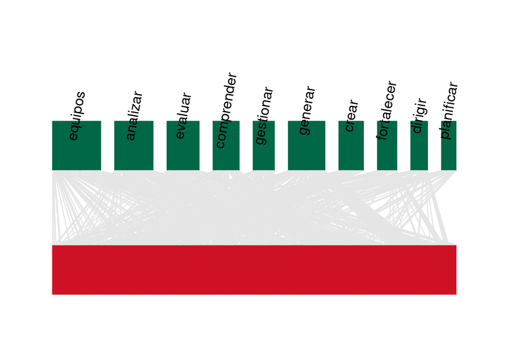

```r
library(bipartite)
plotweb(IARG3, method = "normal",
        col.high = "#006847",
        bor.col.high = "#006847",
        col.low = "#CE1125",
        bor.col.low = "#CE1125",
        col.interaction = "grey90",
        bor.col.interaction = "grey90",
        low.lablength = 0,
        text.rot = 80,
        high.y = 1,
        ybig = 0.8,
        labsize = 2)
```